# Programming Assignment 2

> Name: Sidharth Sharma

In this exercise, you will build regression models to predict house price. Fill in your answers and write your code where appropriate.

- An area where you can write your code will be indicated by these markers.

  “#### ENTER YOUR CODE HERE #####”

  this is the space where you write your code

  “##############################”
- **DO NOT** write your code or modify the code anywhere else.

```r
# Load necessary packages
library(tidyverse)

# for grading
recordAns <- function(varname="unnamed", score, answer, ans_list, score_df){
  score_df <- bind_rows(score_df,  tibble(varname=varname, score=score))
  ans_list[[varname]] <- answer

  return(list(ans_list=ans_list, score_df=score_df))
}

set.seed(321)
```

# 1 Univariate Regression

## 1.1 Data

The dataset that you will use in this section is given in **“housing_data_uni.csv”**. There are two variables in this dataset:

- **medv** – house price in USD (x 1000). This will be the target variable $y$.
- **lstat** – percentage of the population with lower status. This roughly indicates the socio-economic status of the neighborhood around each house. This will be the input variable $x$.

First, you will read the data from this csv file, and store them in a variable named **“housing”**. You can use the `read_csv()` function to read data from the input csv file.

```r
housing <- read_csv("./data/housing_data_uni.csv")
```

It is always a good idea to take a look at the data before processing them. You can use the `glimpse()` function to preview the data.

```r
glimpse(housing)
```

```
Rows: 200
Columns: 2
$ medv  <dbl> 50.0, 21.1, 5.0, 27.5, 13.6, 21.7, 9.7, 23.0, 14.2, 6.3, 7.4, 38.7, 18.6, 28.1, 28.7, 24.6, 21.2, 17.7, 50.0, 20.7, 10.9, 32.5…
$ lstat <dbl> 3.16, 8.01, 22.98, 9.42, 18.07, 13.00, 25.68, 11.12, 15.70, 29.97, 31.99, 4.21, 10.63, 9.38, 5.70, 5.08, 12.34, 14.65, 9.53, 1…
```

As observed, this dataset has 200 rows and 2 columns. Alternatively, you can also use the `head()` function to display the first n rows of the dataset.

```r
# print the first 10 rows
head(housing, 10)
```

| medv | lstat |
| --- | --- |
| 50.0 | 3.16 |
| 21.1 | 8.01 |
| 5.0 | 22.98 |
| 27.5 | 9.42 |
| 13.6 | 18.07 |
| 21.7 | 13.00 |
| 9.7 | 25.68 |
| 23.0 | 11.12 |
| 14.2 | 15.70 |
| 6.3 | 29.97 |

Now, let’s visualize them on a plot. You can use `ggplot()` to create a scatter plot of the two variables.

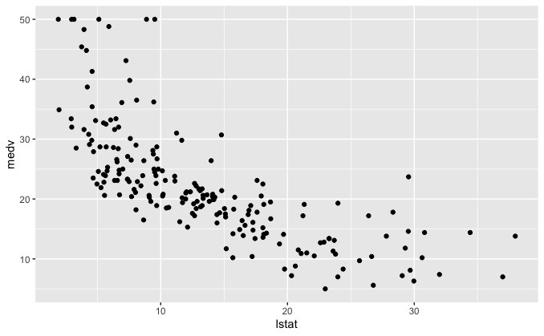

```r
ggplot(data=housing, aes(x=lstat, y=medv)) +
  geom_point()
```

As anticipated, we observe that the house price (**medv**) is negatively correlated with **lstat**. A house is more expensive if it is in a better (economically) neighborhood.

## 1.2 Linear Regression Model

Now, you will build a linear regression model that best fit these data. Particularly, you will find solutions using the two methods discussed in the lectures:

- Normal equation
- Gradient descent

### 1.2.1 Normal Equation

As discussed in the lectures, the normal equation for linear regression can be written as

$$\theta ~=~ \left( X^T X\right)^{-1} X^T y$$

In the following code chunk, you will implement a function named **“normalEq”**, which computes the parameter vector $\theta$ based on the normal equation described above. Here is the input/output specification of the function:

- Inputs:
  - $X$ – Input matrix. It is assumed that the first column of the matrix $X$ contains the bias variable (i.e., $x_0$).
  - $y$ – Target vector.
- Output:
  - $\theta$ – Vector of parameters.

You will add your code below to implement the `normalEq()` function. Note that the function should generally work for an input matrix of size $m \times n$ (i.e., not just a $m \times 2$ matrix in this univariate case).

```r
normalEq <- function(X, y){
  # useful variables
  # It is assumed that the first column of X already has '1' filled up
  n <- ncol(X)

  # Initialize output variable
  theta <- matrix(0, nrow = n, ncol = 1)
  # What is the dimension of this variable
  # This is n rows and 1 col
  #  theta = ||
  #          ||
  #          ||

  ##############################
  # Algorithm
  # [.]1.Check if X^T.X is invertible
  # []  a. If yes Calculate  the inverse
  # []  b. If no return back the error
  # []2. Multiply the result of step 1 to X^T
  # []3. Multiply the result of step 2 of y
  ##############################



  # Step 1:
  X_T <- t(X)
  inner_product <- X_T %*% X
  inverse <- solve(inner_product)
  ## Add debug code

  # Step 2:
  total_X <- inverse %*% X_T
  ## Add debug code

  # Step 3:
  theta <- total_X %*% y




  #### ENTER YOUR CODE HERE #####


  ##############################

  return(theta)
}
```

Now, let’s use the `normalEq()` function to find the model parameters for this dataset.

1. **[1 pt]** Prepare the input matrix $X$. The matrix should have two columns, where the first column is the bias variable ($x_0$) and the second column is the lstat data ($x_1$).

```r
X <- NULL
#### ENTER YOUR CODE HERE #####

# Make the first column of the data frame as 1
# Prepare Bias function
bias <- matrix(1, nrow = 200)

# Separate the lstat variable and add matrix X
# Get the percent of lower status neighbourhood values
X2 <- matrix(housing$lstat,nrow=200)

# Create the input variable that will be passed to the linear regression model
X <- cbind(bias,X2)

##############################
score_df <- tibble()
ans_list <- list()
ans_rec <- recordAns(varname="X_housing1", score=1, answer=X, ans_list=ans_list, score_df=score_df)

# print out a few rows of X
head(X)
```

```
     [,1]  [,2]
[1,]    1  3.16
[2,]    1  8.01
[3,]    1 22.98
[4,]    1  9.42
[5,]    1 18.07
[6,]    1 13.00
```

2. **[1 pt]** Prepare the target vector $y$.

```r
y <- NULL
#### ENTER YOUR CODE HERE #####

# The target varible that we want our model to predict
y <- matrix(housing$medv,nrow=200)

##############################
ans_rec <- recordAns(varname="y_housing1", score=1, answer=y, ans_list=ans_rec$ans_list, score_df=ans_rec$score_df)

# print out a few rows of y
head(y)
```

```
     [,1]
[1,] 50.0
[2,] 21.1
[3,]  5.0
[4,] 27.5
[5,] 13.6
[6,] 21.7
```

3. **[4 pts]** Find the parameter vector $\theta$, using your `normalEq()` function. Observe the value of the parameter vector $\theta$.

```r
theta <- NULL
#### ENTER YOUR CODE HERE #####

theta <- normalEq(X,y)
##############################
ans_rec <- recordAns(varname="theta_housing1", score=4, answer=theta, ans_list=ans_rec$ans_list, score_df=ans_rec$score_df)

print(theta)
```

```
           [,1]
[1,] 34.3117979
[2,] -0.9114341
```

4. **[2 pts]** Use `ggplot()` to create a scatter plot of the input variable (lstat) and the output variable (medv). Draw the regression line on top of the data points. You may use the `geom_abline()` function to draw the regression line. The `geom_abline()` function requires 2 parameters, which are the `slope` and the `intercept`. Store the plot in a variable named **p1**.

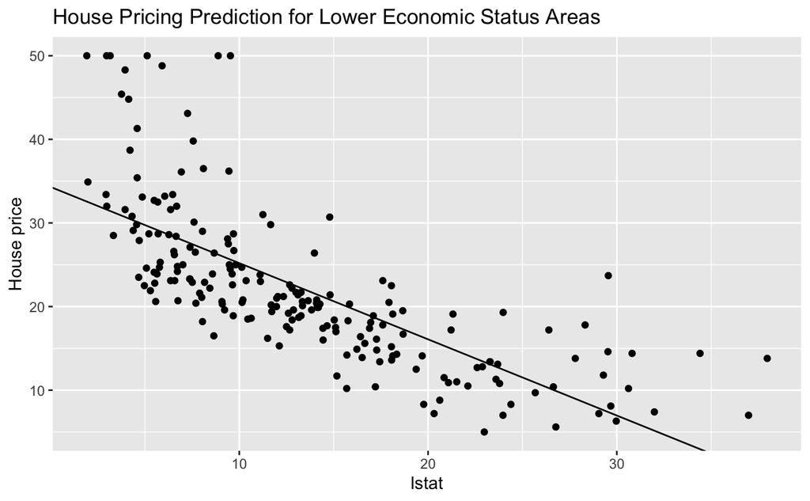

```r
p1 <- NULL
#### ENTER YOUR CODE HERE #####
p0 <- ggplot(data=housing, aes(x=lstat, y=medv)) +
  geom_point()

    # add geometry of the plot (line)
p1 <- p0 + geom_abline(slope = theta[2,1], intercept = theta[1,1]) +
    # add labels
    labs(x="lstat", y="House price", title="House Pricing Prediction for Lower Economic Status Areas")
##############################
ans_rec <- recordAns(varname="p1", score=2, answer=p1, ans_list=ans_rec$ans_list, score_df=ans_rec$score_df)

# print out the plot
p1
```

Next, you will write a function to compute the cost (i.e., the residual sum of squares or RSS in this case). The cost in terms of RSS can be expressed in a matrix form as
$$Cost = (X \theta -y)^T (X \theta -y)$$

You will write a function named **“computeCost”**, to perform this task. Here’s the input/output specification of this function.

- Inputs:
  - $X$ – Input matrix. It is assumed that the first column of the matrix $X$ contains the bias variable ($x_0$).
  - $y$ – Target vector.
  - $\theta$ – Parameter vector.
- Output:
  - $cost$ – Cost of errors.
1. Add your code below to implement the `computeCost()` function. Note that the function should generally work for an input matrix of size $m \times n$ (i.e., not just a $m \times 2$ matrix in this univariate case).

```r
computeCost <- function(X, y, theta){
  # Output variable
  cost <- -1


  #### ENTER YOUR CODE HERE #####
  X_theta <- X %*% theta

  err <- X_theta - y

  cost <- t(err) %*% err
  ##############################

  return(cost)
}
```

2. **[3 pts]** Use the `computeCost()` function to compute the minimum cost attained by the normal solution, and store it in a variable named **min_cost**. Observe the value of **min_cost**.

```r
min_cost <- NULL
#### ENTER YOUR CODE HERE #####
min_cost <- computeCost(X,y,theta)

##############################
ans_rec <- recordAns(varname="min_cost", score=3, answer=min_cost, ans_list=ans_rec$ans_list, score_df=ans_rec$score_df)

print(min_cost)
```

```
         [,1]
[1,] 8461.996
```

### 1.2.2 Batch Gradient Descent

In this section, you will find the parameter vector $\theta$ by using the batch gradient descent (BGD) method. You will be implementing a function named **“batchGradientDescent”**, which searches for the optimal parameter vector $\theta$ using BGD. Here’s the input/output specification for this function:

- Inputs:
  - $X$ – Input matrix. It is assumed that the first column of the matrix $X$ contains the bias variable ($x_0$).
  - $y$ – Target vector.
  - $\alpha$ – Learning rate.
  - max_iter – Maximum number of iterations to loop over.
- Outputs:
  - $\theta$ – Vector of parameters
  - cost_vec – Vector containing the values of cost computed after each iteration of BGD.
1. Write your code below to implement the `batchGradientDescent()` function. Note that the function should generally work for an input matrix of size $m \times n$ (i.e., not just a $m \times 2$ matrix in this univariate case). You should also use the `computeCost()` function to compute the cost after each iteration of BGD.

```r
batchGradientDescent <- function(X, y, alpha = 0.001, max_iter = 100){
  # useful variables
  m <- nrow(X)
  n <- ncol(X)

  # initialize theta to some random numbers
  theta <- matrix(runif(n), nrow = n)
  # initialize cost_vec to -1
  cost_vec <- rep(-1, times = max_iter)

  #### ENTER YOUR CODE HERE ####
  t1 <- rep(1, times = max_iter)
  t2 <- rep(1, times = max_iter)

    for (x in 1:max_iter) {
        # RSS = 2X^T(Xθ−y)
        X_theta = X %*% theta
        x_y <- X_theta- y
        RSS <- (2 * t(X)) %*% x_y
        theta <- theta - alpha * RSS
        t1[x] <- computeCost(X,y,theta)
        t2[x] <- x
      }


  cost_vec <- cbind(t1, t2)



  #############################

  return(list(theta=theta, cost_vec=cost_vec))
}
```

2. **[5 pts]** Now let’s find the parameter vector $\theta$ using the `batchGradientDescent()` function. In the code chunk below, set the value of $\alpha$ to 0.00002, set the value of max_iter to 500, and run the `batchGradientDescent()` function. Store the output in a variable named **“bgd_output”**.

```r
bgd_output <- list(theta=NULL, RSS_vec=NULL)
alpha <- 0.00002
max_iter <- 500
#### ENTER YOUR CODE HERE #####
bgd_output <- batchGradientDescent(X,y,alpha,max_iter)

###############################
ans_rec <- recordAns(varname="bgd_theta_housing1", score=5, answer=bgd_output$theta, ans_list=ans_rec$ans_list, score_df=ans_rec$score_df)
```

The output contains the final parameter vector (**theta**) and the vector of the cost values (**cost_vec**). You can access them by their names (e.g., `bgd_output$theta` and `bgd_output$cost_vec`, respectively) Run the code below to display the parameter vector.

```r
bgd_output$theta
```

```
           [,1]
[1,] 21.9591169
[2,] -0.2144221
```

```r
bgd_output$cost_vec
```

```
             t1  t2
  [1,] 64938.28   1
  [2,] 64512.75   2
  [3,] 64128.49   3
  [4,] 63777.55   4
  [5,] 63453.54   5
  [6,] 63151.34   6
  [7,] 62866.82   7
  [8,] 62596.67   8
  [9,] 62338.22   9
 [10,] 62089.34  10
 [11,] 61848.31  11
 [12,] 61613.76  12
 [13,] 61384.56  13
 [14,] 61159.82  14
```

[output cut: 486 more lines]

3. **[2 pts]** Use `ggplot()` to plot the cost values in **cost_vec** as a function of iteration. Add a straight horizontal line to the plot. The y-coordinate of the horizontal line should be equal to **min_cost**. Store the plot in a variable named **p2**.

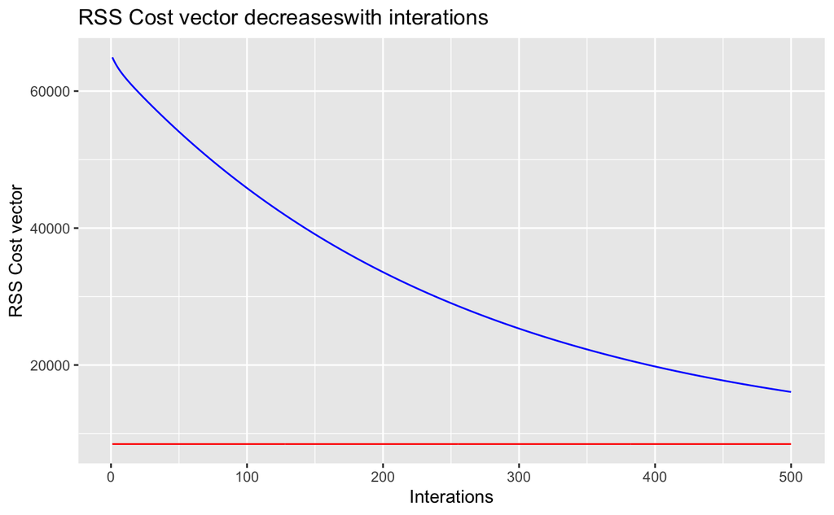

```r
p2 <- NULL

#### ENTER YOUR CODE HERE #####
#p3 <- ggplot(data=housing, aes(x=lstat, y=medv)) +
#  geom_point()


    # add geometry of the plot (line)
p21 <- ggplot(as.data.frame(bgd_output$cost_vec)) +
    # add geometry of the plot (line)
    geom_line(aes(x=bgd_output$cost_vec[,2], y=bgd_output$cost_vec[,1]), color = "blue")

p2 <- p21 + geom_line(aes(x=bgd_output$cost_vec[,2], y=min_cost), color = "red")+
    # add labels: min_cost
    labs(x="Interations", y="RSS Cost vector", title="RSS Cost vector decreaseswith interations")
###############################
ans_rec <- recordAns(varname="p2", score=2, answer=p2, ans_list=ans_rec$ans_list, score_df=ans_rec$score_df)



p2
```

- Does the cost reach the **min_cost** with these values of $\alpha$ and max_iter?

(Side note: Not to be included in this assignment, but try for yourself to see if using $\alpha$ = 0.001 makes BGD converge in this case.)

### 1.2.3 Feature Scaling

In this section, you will implement a feature scaling function named **“featureScaling”**. This function will scale the feature in each column of an input matrix $X$ (except the bias variable $x_0$) with mean normalization. The mean normalization is given as

$$z = \frac{x - \overline{x}}{\max{(x)} - \min{(x)}}$$

Here’s the input/output specification for the `featureScaling()` function:

- Input:
  - $X$ – Input matrix. It is assumed that the first column of the matrix $X$ contains the bias variable ($x_0$).
- Outputs:
  - $Z$ – A matrix after feature scaling (it should have the same dimension as $X$).
  - xmax – A vector storing the max of each column of $X$.
  - xmin – A vector storing the min of each column of $X$.
1. Add your code below to implement the `featureScaling()` function.

```r
featureScaling <- function(X){
  # useful vars
  m <- nrow(X)
  n <- ncol(X)

  # initialize output var
  Z <- matrix(0, ncol = n, nrow = m)
  xmax <- matrix(0, ncol = n)
  xmin <- matrix(0, ncol = n)
  xmean <- matrix(0, ncol = n)
  Xscaled <- matrix(0, ncol = n, nrow = m)
  for (x in 2:n) {
    xmax[x]  <- max(X[,x])
    xmin[x]  <- min(X[,x])
    xmean[x] <- mean(X[,x])
  }
  # Remember that we do not scale x_0
  #### ENTER YOUR CODE HERE #####
    X1 <- X[,1]
   for (t in 2:n) {
    denom <- xmax[t] - xmin[t]
    Xscaled[,t] <- (X[,t] - xmean[t]) /  denom
   }
  Z <- cbind(X1,Xscaled[,2:n])

  #############################
  return(list(Z=Z,xmax=xmax,xmin=xmin))
}
```

2. **[3 pts]** Use the `featureScaling()` function to scale the feature of the input $X$, and store the output in a new matrix $Z$. Take a look at the matrix $Z$ and make sure that the features are scaled as expected.

```r
Z <- NULL
#### ENTER YOUR CODE HERE #####
Z <- featureScaling(X)

#############################
ans_rec <- recordAns(varname="Z_housing1", score=3, answer=Z, ans_list=ans_rec$ans_list, score_df=ans_rec$score_df)

head(Z$Z)
```

```
     X1
[1,]  1 -0.281785021
[2,]  1 -0.147249653
[3,]  1  0.268006935
[4,]  1 -0.108137309
[5,]  1  0.131807212
[6,]  1 -0.008830791
```

3. **[2 pt]** Use $Z$ as an input, set $\alpha$ = 0.001, max_iter = 150, and run the `batchGradientDescent()` function. Store the output of the function in a variable named **“bgd_output_fs”**.

```r
bgd_output_fs <- list(theta=NULL, cost_vec=NULL)
alpha <- 0.001
max_iter <- 150
#### ENTER YOUR CODE HERE #####
bgd_output_fs <- batchGradientDescent(Z$Z,y,alpha,max_iter)

#############################
ans_rec <- recordAns(varname="bgd_theta_fs_housing1", score=2, answer=bgd_output_fs$theta, ans_list=ans_rec$ans_list, score_df=ans_rec$score_df)

bgd_output_fs$theta
```

```
        [,1]
X1  22.17300
   -30.68828
```

```r
bgd_output_fs$cost_vec
```

```
              t1  t2
  [1,] 52057.613   1
  [2,] 30164.666   2
  [3,] 22067.328   3
  [4,] 18944.167   4
  [5,] 17619.186   5
  [6,] 16948.760   6
  [7,] 16520.924   7
  [8,] 16187.120   8
  [9,] 15893.627   9
 [10,] 15620.875  10
 [11,] 15361.592  11
 [12,] 15112.946  12
 [13,] 14873.710  13
 [14,] 14643.240  14
```

[output cut: 136 more lines]

4. **[2 pts]** Use `ggplot()` to plot the cost values in cost_vec as a function of iteration. Add a straight horizontal line to the plot. The y-coordinate of the horizontal line should be equal to min_cost. Store the plot in a variable named **p3**.

```r
p3 <- NULL
#### ENTER YOUR CODE HERE #####

min_cost <- computeCost(Z$Z,y,bgd_output_fs$theta)
print(min_cost)
```

```
         [,1]
[1,] 8504.638
```

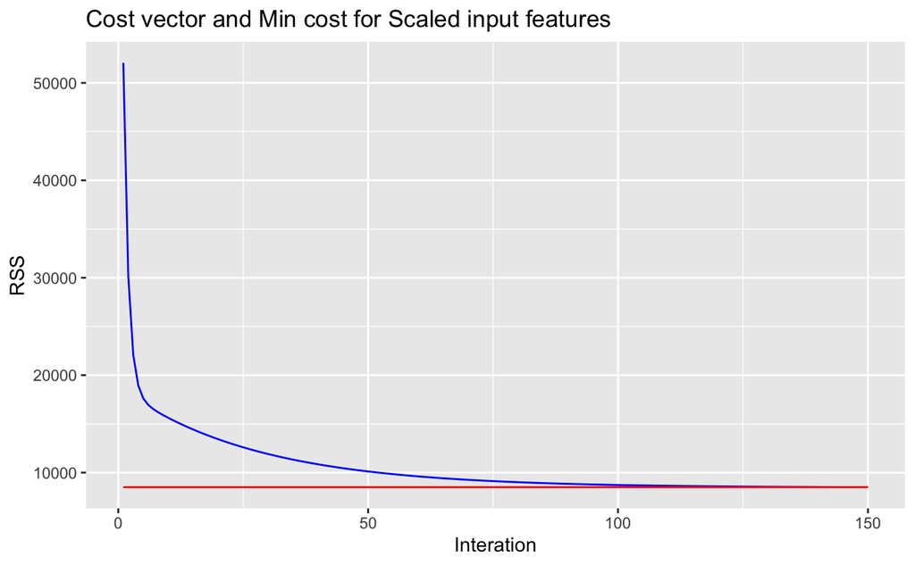

```r
p31 <- ggplot(as.data.frame(bgd_output_fs$cost_vec)) +
  geom_line( aes(x=bgd_output_fs$cost_vec[,2], y=bgd_output_fs$cost_vec[,1]), color='blue')

    # add geometry of the plot (line)
p3 <- p31 + geom_line(aes(x=bgd_output_fs$cost_vec[,2], y=min_cost), color='red') +
    # add labels
    labs(x="Interation", y="RSS", title="Cost vector and Min cost for Scaled input features")

#############################
ans_rec <- recordAns(varname="p3", score=2, answer=p3, ans_list=ans_rec$ans_list, score_df=ans_rec$score_df)

p3
```

- Does the cost reach the min_cost with these values of $\alpha$ and max_iter?

**Feature scaling helps BGD converge faster.** In general, it is a good practice to scale your features before doing BGD.

# 2 Multivariate Regression

In this section, we will consider multivariate linear regression. Instead of having only one input feature, we will consider more input features in the model. However, the basic ideas developed in the previous section still apply.

## 2.1 Data

The dataset that you will use in this section is given in **“housing_data_multi.csv”**. There are six variables in this dataset:

- **medv** – house price in USD (x 1000). This will be the target variable $y$.
- **lstat** – percentage of the population with lower status. This roughly indicates the socio-economic status of the neighborhood around each house.
- **rm** – average number of rooms per dwelling.
- **crim** – per capita crime rate by town.
- **tax** – full-value property-tax rate per $10,000.
- **ptratio** – pupil-teacher ratio by town.

First, you will read the data from this csv file, and store them in a variable named **“housing2”**. You can use the `read_csv()` function to read the input csv data.

```r
housing2 <- read_csv("./data/housing_data_multi.csv")
```

You can use the `glimpse()` function to preview the data.

```r
glimpse(housing2)
```

```
Rows: 200
Columns: 6
$ medv    <dbl> 50.0, 21.1, 5.0, 27.5, 13.6, 21.7, 9.7, 23.0, 14.2, 6.3, 7.4, 38.7, 18.6, 28.1, 28.7, 24.6, 21.2, 17.7, 50.0, 20.7, 10.9, 32…
$ lstat   <dbl> 3.16, 8.01, 22.98, 9.42, 18.07, 13.00, 25.68, 11.12, 15.70, 29.97, 31.99, 4.21, 10.63, 9.38, 5.70, 5.08, 12.34, 14.65, 9.53,…
$ rm      <dbl> 7.923, 6.037, 5.683, 6.727, 5.983, 6.195, 5.036, 6.372, 6.006, 5.852, 5.000, 8.069, 6.405, 6.375, 7.079, 6.431, 6.232, 6.376…
$ crim    <dbl> 0.01501, 0.03961, 67.92080, 0.14866, 0.10574, 0.10793, 11.57790, 0.59005, 7.02259, 9.91655, 22.59710, 0.12083, 0.22876, 0.14…
$ tax     <dbl> 198, 224, 666, 384, 711, 384, 666, 437, 666, 666, 666, 276, 384, 277, 270, 287, 398, 666, 666, 223, 666, 193, 284, 222, 391,…
$ ptratio <dbl> 13.6, 20.2, 20.2, 20.9, 20.1, 20.9, 20.2, 21.2, 20.2, 20.2, 20.2, 18.0, 20.9, 18.6, 17.8, 19.6, 18.7, 20.2, 20.2, 18.6, 20.2…
```

As observed, the dataset has 200 rows and 6 columns.

## 2.2 Normal Equation

You will build a regression model that predicts house price based on the 5 input features given in the dataset. The model can be expressed as
$$\hat{y} = \theta_0 + \theta_1 x_1 + \theta_2 x_2 + \theta_3 x_3 +
\theta_4 x_4 + \theta_5 x_5$$
where $x_1$ is lstat, $x_2$ is rm, $x_3$ is crim, $x_4$ is tax, and $x_5$ is ptratio.

Let’s use the `normalEq()` function that you developed in the previous section to solve for the optimal parameter $\theta$.

1. **[1 pt]** Prepare the input matrix $X$. The matrix should have 6 columns, where the first column is the bias variable ($x_0$), and the rest are the 5 input features.

```r
X <- NULL
#### ENTER YOUR CODE HERE #####
m <- matrix(1, nrow = 200)
#glimpse(m)
X1 <- matrix(housing2$lstat,nrow=200)
X2 <- matrix(housing2$rm,nrow=200)
X3 <- matrix(housing2$crim,nrow=200)
X4 <- matrix(housing2$tax,nrow=200)
X5 <- matrix(housing2$ptratio,nrow=200)

X <- cbind(m,X1,X2,X3,X4,X5)

##############################
ans_rec <- recordAns(varname="X_housing2", score=1, answer=X, ans_list=ans_rec$ans_list, score_df=ans_rec$score_df)

head(X)
```

```
     [,1]  [,2]  [,3]     [,4] [,5] [,6]
[1,]    1  3.16 7.923  0.01501  198 13.6
[2,]    1  8.01 6.037  0.03961  224 20.2
[3,]    1 22.98 5.683 67.92080  666 20.2
[4,]    1  9.42 6.727  0.14866  384 20.9
[5,]    1 18.07 5.983  0.10574  711 20.1
[6,]    1 13.00 6.195  0.10793  384 20.9
```

2. **[1 pt]** Prepare the response vector $y$.

```r
y <- NULL
#### ENTER YOUR CODE HERE #####

y <- matrix(housing2$medv,nrow=200)
##############################
ans_rec <- recordAns(varname="y_housing2", score=1, answer=y, ans_list=ans_rec$ans_list, score_df=ans_rec$score_df)

head(y)
```

```
     [,1]
[1,] 50.0
[2,] 21.1
[3,]  5.0
[4,] 27.5
[5,] 13.6
[6,] 21.7
```

3. **[1 pt]** Find the optimal parameter $\theta$ using the `normalEq()` function.

```r
theta <- NULL
#### ENTER YOUR CODE HERE #####
  # Initialize output variable

#theta <- matrix(0, nrow = n, ncol = 1)

   #### ENTER YOUR CODE HERE #####
  # What is the dimension of this variable
  # This is n rows and 1 col
  #  theta = ||
  #          ||
  #          ||

  ##############################
  # Algorithm
  # [.]1.Check if X^T.X is invertible
  # [.]  a. If yes Calculate  the inverse
  # [.]  b. If no return back the error
  # [.]2. Multiply the result of step 1 to X^T
  # [.]3. Multiply the result of step 2 of y
  ##############################



  # Step 1:
  X_T <- t(X)
  inner_product <- X_T %*% X
  inverse <- solve(inner_product)
  ## Add debug code

  # Step 2:
  total_X <- inverse %*% X_T
  ## Add debug code

  # Step 3:
  theta <- total_X %*% y

##############################
ans_rec <- recordAns(varname="theta_housing2", score=1, answer=theta, ans_list=ans_rec$ans_list, score_df=ans_rec$score_df)

print(theta)
```

```
             [,1]
[1,] 13.851498783
[2,] -0.370504548
[3,]  5.200425737
[4,] -0.082838582
[5,] -0.005629463
[6,] -0.895211905
```

4. **[1 pt]** Compute the minimum cost attained by the normal solution, using the `computeCost()` function. Store the cost in a variable named **min_cost_multi**. Observe the value of **min_cost_multi**.

```r
min_cost_multi <- NULL
#### ENTER YOUR CODE HERE #####

min_cost_multi <- computeCost(X,y,theta)
##############################
ans_rec <- recordAns(varname="min_cost_multi", score=1, answer=min_cost_multi, ans_list=ans_rec$ans_list, score_df=ans_rec$score_df)

min_cost_multi
```

```
         [,1]
[1,] 5464.833
```

## 2.3 Gradient Descent

In this section, you will find the parameters of the model with BGD.

1. **[1 pt]** First, let’s use the `featureScaling()` function to scale the features in the input matrix $X$. Store the scaled input matrix in a new matrix named $Z$.

```r
Z <- NULL
#### ENTER YOUR CODE HERE #####
#glimpse(X)
Z<-featureScaling(X)
#glimpse(Z)
##############################
ans_rec <- recordAns(varname="Z_housing2", score=1, answer=Z, ans_list=ans_rec$ans_list, score_df=ans_rec$score_df)

head(Z$Z)
```

```
     X1
[1,]  1 -0.281785021  0.35428264 -0.04952907 -0.42656788 -0.5563889
[2,]  1 -0.147249653 -0.05200776 -0.04925255 -0.37685468  0.1769444
[3,]  1  0.268006935 -0.12826799  0.71377303  0.46826960  0.1769444
[4,]  1 -0.108137309  0.09663507 -0.04802676 -0.07092734  0.2547222
[5,]  1  0.131807212 -0.06364067 -0.04850921  0.55431166  0.1658333
[6,]  1 -0.008830791 -0.01797070 -0.04848459 -0.07092734  0.2547222
```

2. **[1 pt]** Find the optimal parameters using the `batchGradientDescent()` function. In the code chunk below, set $\alpha$ = 0.001, max_iter = 150, and run the `batchGradientDescent()` function. Store the output of the function in a variable named **“bgd_output”**.

```r
bgd_output <- list(theta=NULL, cost_vec=NULL)
alpha <- 0.001
max_iter <- 150
#### ENTER YOUR CODE HERE #####

bgd_output <- batchGradientDescent(Z$Z,y,alpha,max_iter)
###############################
ans_rec <- recordAns(varname="bgd_theta_housing2", score=1, answer=bgd_output$theta, ans_list=ans_rec$ans_list, score_df=ans_rec$score_df)

bgd_output$theta
```

```
         [,1]
X1  22.173000
   -15.796262
    17.560170
    -4.060208
    -3.739047
    -8.823023
```

3. **[1 pt]** Use `ggplot()` to plot the cost values in **cost_vec** as a function of iteration. Add a straight horizontal line to the plot. The y-coordinate of the horizontal line should be equal to **min_cost_multi**. Store the plot in a variable named **p4**

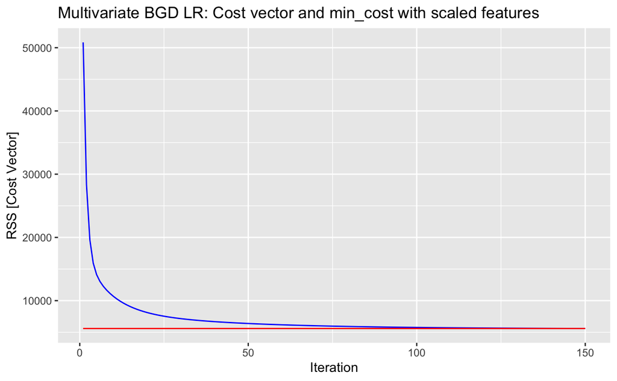

```r
p4 <- NULL
#### ENTER YOUR CODE HERE #####

min_cost_multi <- computeCost(Z$Z,y,bgd_output$theta)

p41 <- ggplot(as.data.frame(bgd_output$cost_vec)) +
  geom_line( aes(x=bgd_output$cost_vec[,2], y=bgd_output$cost_vec[,1]), color='blue')

    # add geometry of the plot (line)
p4 <- p41 + geom_line(aes(x=bgd_output$cost_vec[,2], y=min_cost_multi), color='red') +
    # add labels
    labs(x="Iteration", y="RSS [Cost Vector]", title="Multivariate BGD LR: Cost vector and min_cost with scaled features")
###############################
ans_rec <- recordAns(varname="p4", score=1, answer=p4, ans_list=ans_rec$ans_list, score_df=ans_rec$score_df)

p4
```

- Does your cost reach the **min_cost_multi** with these values of $\alpha$ and max_iter?

# 3 Ridge Regression

In this section, you will implement ridge regression and regularization.

## 3.1 Data

The dataset that you will use in this section is **“housing_data_rgd.csv”**. All the variables are the same as those previously considered in the multivariate regression problem, except one additional variable. The new variable is

- **qua** – the overall quality of neighborhood.

First, you will read the data from this csv file, and store them into a variable named **“housing3”**. You can use the `read_csv()` function to read the input csv data.

```r
housing3 <- read_csv("./data/housing_data_rgd.csv")
```

## 3.2 Normal Equation

You will build a regression model that predicts house price based on the 6 input features given in the dataset. The model can be expressed as
$$\hat{y} = \theta_0 + \theta_1 x_1 + \theta_2 x_2 + \theta_3 x_3 +
\theta_4 x_4 + \theta_5 x_5 + \theta_6 x_6$$
where $x_1$ is lstat, $x_2$ is rm, $x_3$ is crim, $x_4$ is tax, $x_5$ is ptratio, and $x_6$ is qua.

Let’s use the `normalEq()` function that you developed in the earlier section to solve for the optimal parameter $\theta$.

4. Write a function named **“ridgeRegression”**, which solves for the parameter $\theta_R$ as described in the above equation. Here’s the input/output specification for this function:
- Inputs:
  - $X$ – Input matrix. It is assumed that the first column of the matrix $X$ contains the bias variable ($x_0$).
  - $y$ – Target vector.
  - $\lambda$ – A positive number for adjusting the degree of regularization.
- Output:
  - $\theta_R$ – Vector of parameters.
5. **[4 pts]** Now, use the `ridgeRegression()` function to find the parameter $\theta_R$. Set $\lambda = 0.01$. Store the result in a variable named **theta_R**.
6. **[1 pt]** Use the obtained parameters **theta_R** to predict the price of the input $X$. Store the predicted price in a variable named **y_pred_ridge**

## 3.3 Gradient Descent

In this section, you will implement ridge regression using the gradient descent method. As discussed in the lecture, in ridge regression, the cost is modified by adding the regularization terms as follows
$$Cost = \sum_{i=1}^{m} (\theta_0 + \theta_1 x_1^{(i)} + \dots + \theta_n
x_n^{(i)} - y)^2 + \lambda \sum_{j=1}^{n} \theta_j^2$$

In the code chunk below, implement the `computeCostReg()` function to compute the above cost. Here’s the input/output specification of this function.

- Inputs:
  - $X$ – Input matrix. It is assumed that the first column of the matrix $X$ contains the bias variable ($x_0$).
  - $y$ – Target vector.
  - $\theta$ – Parameter vector.
  - $\lambda$ – The regularization parameter
- Output:
  - $cost$ – Cost of errors.

Next, you will implement a regularized version of the `batchGradientDescent()` function. Let’s call this function `batchGradientDescentReg()`. Here’s the input/output specification for this function:

- Inputs:
  - $X$ – Input matrix. It is assumed that the first column of the matrix $X$ contains the bias variable ($x_0$).
  - $y$ – Target vector.
  - $\alpha$ – Learning rate.
  - max_iter – Maximum number of iterations to loop over.
  - lambda – A positive number for adjusting the degree of regularization.
- Outputs:
  - $\theta$ – Vector of parameters
  - cost_vec – Vector containing the value of cost after each iteration of BGD
1. Add your code below to implement the `batchGradientDescentReg()` function. You should also use the `computeCostReg()` function to compute the cost after each iteration of BGD.
2. **[1 pt]** Scale the features with the `featureScaling()` function. Store the scaled inputs in a new matrix named $Z$.
3. **[4 pts]** Find the optimal parameter for the regularized linear regression model, using the `batchGradientDescentReg()` function. Set $\alpha = 0.001$, max_iter = 1000, and $\lambda = 0.01$. Store the output of the function in a variable named **“bgd_output_reg”**.
4. **[1 pt]** Use the obtained parameters **bgd_output_reg$theta** to predict the price of the normalized input $Z$. Store the predicted price in a variable named **y_pred_reg**
- Are these predicted prices the same (sufficiently close) to what you obtained from ridge regression?
5. **[1 pt]** Find the optimal parameter for the regularized linear regression model, using the `batchGradientDescentReg()` function. Set $\alpha = 0.001$, max_iter = 1000, and $\lambda = 10$. Store the output of the function in a variable named **“bgd_output_reg2”**.
6. **[1 pt]** Find the optimal parameter for the regularized linear regression model, using the `batchGradientDescentReg()` function. Set $\alpha = 0.001$, max_iter = 1000, and $\lambda = 100$. Store the output of the function in a variable named **“bgd_output_reg3”**.
7. **[2 pts]** Create a data frame named **theta_params**, where its 1st column is the $\theta$ in **bgd_output_reg**, its 2nd column is the $\theta$ in **bgd_output_reg2**, and the last column is the $\theta$ in **bgd_output_reg3**. Name the columns as l1, l2, and l3, respectively. You should observe how the value of $\lambda$ affects the model parameters $\theta$.

# 4 Bias-Variance Tradeoff

In this section, we will use a regularization technique to reduce variance and prevent overfitting. Recall that the hyper-parameter that we can tune in regularized linear regression is the parameter $\lambda$. Increasing the value of $\lambda$ helps decrease the variance but also increases the bias. We need to strike a balance between these two quantities. The goal in this exercise is to choose an appropriate value of $\lambda$ for our model.

The data that you will use in this exercise are given in these two files: (i) **mpg_training.csv** and (ii) **mpg_cv.csv**. Each of these files contains the fuel efficiency (in miles/gallon) and other features of a vehicle (e.g., number of cylinders, horse power, weight, etc.) You will build a linear regression model that predicts the fuel efficiency of a vehicle based on these given features.

1. Read data from **mpg_training.csv**, and store them in a variable named **tr**. Read data from **mpg_cv.csv**, and store them in a variable named **cv**.
- Now let’s take a look at the data in the **tr** set. Use the `glimpse()` command to preview the data. You should see that the dataset contains 11 variables. The first variable (first column) is **mpg**. This will be the target variable. The rest of the variables will be used as input features.
2. **[4 pts]** Create the following variables:
   - $X_{tr}$ – An input matrix containing the input features in the **tr** set, with an augmented variable $x_0 = 1$ in its first column. Totally, $X_{tr}$ should have 11 columns (including $x_0$).
   - $y_{tr}$ – The target variable in the **tr** set. This would be the **mpg**.
   - $X_{cv}$ – An input matrix containing the input features in the **cv** set, with an augmented variable $x_0 = 1$ in its first column. Totally, $X_{cv}$ should have 11 columns (including $x_0$).
   - $y_{cv}$ – The target variable in the **cv** set. This would be the **mpg**.
3. In the code chunk below, you will implement a z-score normalization function named **zNormalize**. In z-score normalization, an input $x$ is normalized with its mean and standard deviation as follows:
   $$z = \frac{x-\overline{x}}{\sigma}$$
   where $\overline{x}$ is the mean of $x$ and $\sigma$ is its standard deviation. Here’s the specification of the function:
   - Input:
     - $X$ – An input matrix. It is assumed that the first column of $X$ contains $x_0 = 1$.
   - Outputs:
     - $Z$ – A matrix of scaled inputs. $Z$ should have the same dimension as $X$. Do not normalize $x_0$.
     - xbar – A vector storing the mean of each column of $X$.
     - sigma – A vector storing the standard deviation of each column of $X$.
4. Another popular metric that is typically used to the compare the performance of linear regression models is the mean squared error (MSE), which is defined as

$$MSE = \frac{1}{m} \sum_{i=1}^{m} \left( \theta_0 + \theta_1 x_1^{(i)} +
\dots + \theta_n x_n^{(i)} - y^{(i)} \right)^2$$

Next, you will write a function that builds a regularized linear regression model on the **tr** data and validates its performance on the **cv** data. Let’s call this function **cvReg**. Here’s the input/output specification for this function:

- Inputs:
  - $X_{tr}$ – An input matrix created from the **tr** set (done in the previous step)
  - $y_{tr}$ – The target varaible $y$ from the **tr** set (done in the previous step)
  - $X_{cv}$ – – An input matrix created from the **cv** set (done in the previous step)
  - $y_{cv}$ – The target varaible $y$ from the **cv** set (done in the previous step)
  - $\alpha$ – The learning rate (for BGD)
  - max_iter – The maximum number of iterations (for BGD)
  - $\lambda$ – The regularization parameter
- Outputs:
  - $\theta$ – The parameter vector
  - MSE_tr – The MSE on the **tr** set
  - MSE_cv – The MSE on the **cv** set

  Here are a few steps that you should take:
  - With the input matrix $X_{tr}$, use (regularized) batch gradient descent to find the model parameter $\theta$. Don’t forget to scale your features. You should use the `zNormalize()` function developed earlier.
  - Find the MSE on the **tr** set and store it in a variable named **MSE_tr**
  - Perform z-score normalization for each column of $X_{cv}$. You should normalize the features in $X_{cv}$ with the same set of values (i.e., mean, sigma) used in normalizing the features in the matrix $X_{tr}$.
  - Use the obtained $\theta$ to predict the target variable on the **cv** set. Find the MSE and store it in a variable named **“MSE_cv”**.
  - You may want to use the `batchGradientDescentReg()` function developed earlier.
5. **[5 pts]** Use the following values of $\lambda$ as inputs to the `cvReg()` function.
   $$\lambda \in (0, 0.1, 0.5, 1, 5, 10, 20)$$
   For each value of $\lambda$, record the MSE_tr and the MSE_cv returned by the `cvReg()` function. Finally, store $\lambda$, MSE_tr, MSE_cv in a data frame named **result_reg**. Your data frame should have 7 rows and 3 columns.
6. **[2 pts]** Use `ggplot()` to plot MSE_tr and MSE_cv as a function of $\lambda$. Both MSE_tr and MSE_cv should be on the same figure. Label all axes. Use legend to indicate cleary which curve is MSE_tr and which curve is MSE_cv. Store the plot in a variable named **p5**.

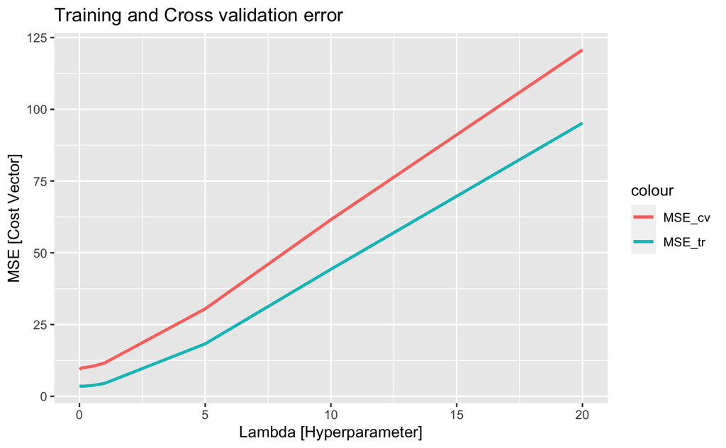

```r
p5 <- NULL
#### ENTER YOUR CODE HERE ####

p51 <- ggplot(result) +
  geom_line( aes(x=lambda, y=MSE_tr,colour="MSE_tr"), size=1)

    # add geometry of the plot (line)
p5 <- p51 + geom_line(aes(x=lambda, y=MSE_cv,colour="MSE_cv"),size=1) +
    # add labels
    labs(x="Lambda [Hyperparameter]", y="MSE [Cost Vector]", title="Training and Cross validation error")


############################
ans_rec <- recordAns(varname="p5", score=2, answer=p5, ans_list=ans_rec$ans_list, score_df=ans_rec$score_df)

p5
```

[output not shown]

7. **[1 pt]** Based on the plot created in step 5, what would be the appropriate value of $\lambda$ that you would use? Why? Type you answer in the space below.

# 5 Grading

This part is for the grading purpose. **DO NOT modify anything in this section.**

- Scores list
- Print out the answers.
1. X_housing1 … 1 pts
2. y_housing1 … 1 pts
3. theta_housing1 … 4 pts
4. p1 … 2 pts
5. min_cost … 3 pts
6. bgd_theta_housing1 … 5 pts
7. p2 … 2 pts
8. Z_housing1 … 3 pts
9. bgd_theta_fs_housing1 … 2 pts
10. p3 … 2 pts
11. X_housing2 … 1 pts
12. y_housing2 … 1 pts
13. theta_housing2 … 1 pts
14. min_cost_multi … 1 pts
15. Z_housing2 … 1 pts
16. bgd_theta_housing2 … 1 pts
17. p4 … 1 pts
18. X_housing3 … 1 pts
19. y_housing3 … 1 pts
20. theta_R_housing3 … 4 pts
21. y_pred_ridge_housing3 … 1 pts
22. Z_housing3 … 1 pts
23. bgd_theta_housing3 … 4 pts
24. y_pred_reg_housing3 … 1 pts
25. bgd_theta2_housing3 … 1 pts
26. bgd_theta3_housing3 … 1 pts
27. bgd_theta_params_housing3 … 2 pts
28. X_tr_mpg … 1 pts
29. y_tr_mpg … 1 pts
30. X_cv_mpg … 1 pts
31. y_cv_mpg … 1 pts
32. result_reg_mpg … 5 pts
33. p5 … 2 pts